# Regression and Variable Selection

# 1 Objective

The objective of this case is to get you started with regression model building, variable selection, and model evaluation in R.

We use Boston Housing Data as an illustrative example in this lab. We learn basic linear regression and analysis with R. Code in this file is not the only correct way to do things, however it is important for you to understand what each statement does. You will have to modify the code accordingly for your homework.

# 2 Boston Housing Data

Boston housing data is a built-in dataset in `MASS` package, so you do not need to download externally. Package `MASS` comes with R when you installed R, so no need to use `install.packages(MASS)` to download and install, but you do need to load this package.

## 2.1 Load Data

```r
library(MASS)
data(Boston); #this data is in MASS package
colnames(Boston)
```

```
##  [1] "crim"    "zn"      "indus"   "chas"    "nox"     "rm"      "age"
##  [8] "dis"     "rad"     "tax"     "ptratio" "black"   "lstat"   "medv"
```

You can find details of the dataset from help document.

```r
?Boston
```

The original data are 506 observations on 14 variables, medv being the response variable $y$:

## 2.2 EDA

We have introduced many EDA techniques in lab 2. We will briefly go through some of them here.

```r
dim(Boston)
```

```
## [1] 506  14
```

```r
names(Boston)
```

```
##  [1] "crim"    "zn"      "indus"   "chas"    "nox"     "rm"      "age"
##  [8] "dis"     "rad"     "tax"     "ptratio" "black"   "lstat"   "medv"
```

```r
str(Boston)
```

```
## 'data.frame':    506 obs. of  14 variables:
##  $ crim   : num  0.00632 0.02731 0.02729 0.03237 0.06905 ...
##  $ zn     : num  18 0 0 0 0 0 12.5 12.5 12.5 12.5 ...
##  $ indus  : num  2.31 7.07 7.07 2.18 2.18 2.18 7.87 7.87 7.87 7.87 ...
##  $ chas   : int  0 0 0 0 0 0 0 0 0 0 ...
##  $ nox    : num  0.538 0.469 0.469 0.458 0.458 0.458 0.524 0.524 0.524 0.524 ...
##  $ rm     : num  6.58 6.42 7.18 7 7.15 ...
##  $ age    : num  65.2 78.9 61.1 45.8 54.2 58.7 66.6 96.1 100 85.9 ...
##  $ dis    : num  4.09 4.97 4.97 6.06 6.06 ...
##  $ rad    : int  1 2 2 3 3 3 5 5 5 5 ...
##  $ tax    : num  296 242 242 222 222 222 311 311 311 311 ...
##  $ ptratio: num  15.3 17.8 17.8 18.7 18.7 18.7 15.2 15.2 15.2 15.2 ...
##  $ black  : num  397 397 393 395 397 ...
##  $ lstat  : num  4.98 9.14 4.03 2.94 5.33 ...
##  $ medv   : num  24 21.6 34.7 33.4 36.2 28.7 22.9 27.1 16.5 18.9 ...
```

```r
summary(Boston)
```

```
##       crim                zn             indus            chas
##  Min.   : 0.00632   Min.   :  0.00   Min.   : 0.46   Min.   :0.00000
##  1st Qu.: 0.08204   1st Qu.:  0.00   1st Qu.: 5.19   1st Qu.:0.00000
##  Median : 0.25651   Median :  0.00   Median : 9.69   Median :0.00000
##  Mean   : 3.61352   Mean   : 11.36   Mean   :11.14   Mean   :0.06917
##  3rd Qu.: 3.67708   3rd Qu.: 12.50   3rd Qu.:18.10   3rd Qu.:0.00000
##  Max.   :88.97620   Max.   :100.00   Max.   :27.74   Max.   :1.00000
##       nox               rm             age              dis
##  Min.   :0.3850   Min.   :3.561   Min.   :  2.90   Min.   : 1.130
##  1st Qu.:0.4490   1st Qu.:5.886   1st Qu.: 45.02   1st Qu.: 2.100
##  Median :0.5380   Median :6.208   Median : 77.50   Median : 3.207
##  Mean   :0.5547   Mean   :6.285   Mean   : 68.57   Mean   : 3.795
##  3rd Qu.:0.6240   3rd Qu.:6.623   3rd Qu.: 94.08   3rd Qu.: 5.188
##  Max.   :0.8710   Max.   :8.780   Max.   :100.00   Max.   :12.127
##       rad              tax           ptratio          black
##  Min.   : 1.000   Min.   :187.0   Min.   :12.60   Min.   :  0.32
##  1st Qu.: 4.000   1st Qu.:279.0   1st Qu.:17.40   1st Qu.:375.38
##  Median : 5.000   Median :330.0   Median :19.05   Median :391.44
##  Mean   : 9.549   Mean   :408.2   Mean   :18.46   Mean   :356.67
##  3rd Qu.:24.000   3rd Qu.:666.0   3rd Qu.:20.20   3rd Qu.:396.23
##  Max.   :24.000   Max.   :711.0   Max.   :22.00   Max.   :396.90
##      lstat            medv
##  Min.   : 1.73   Min.   : 5.00
##  1st Qu.: 6.95   1st Qu.:17.02
##  Median :11.36   Median :21.20
##  Mean   :12.65   Mean   :22.53
##  3rd Qu.:16.95   3rd Qu.:25.00
##  Max.   :37.97   Max.   :50.00
```

We skip the Exploratory Data Analysis (EDA) in this notes, but you should not omit it in your HW and Cases. EDA is very important and always the first analysis to do before any modeling.

## 2.3 Preparation

### 2.3.1 Splitting data to training and testing samples

Next we sample 90% of the original data and use it as the training set. The remaining 10% is used as test set. The regression model will be built on the training set and future performance of your model will be evaluated with the test set.

```r
sample_index <- sample(nrow(Boston),nrow(Boston)*0.90)
Boston_train <- Boston[sample_index,]
Boston_test <- Boston[-sample_index,]
```

### 2.3.2 (Optional) Standardization

If we want our results to be invariant to the units and the parameter estimates $\beta_i$ to be comparible, we can standardize the variables. Essentially we are replacing the original values with their z-score.

1st Way: create new variables manually.

```r
Boston$sd.crim <- (Boston$crim-mean(Boston$crim))/sd(Boston$crim);
```

This does the same thing.

```r
Boston$sd.crim <- scale(Boston$crim);
```

2nd way: If you have a lot of variables to standardize then the above is not very pleasing to do. You can use a loop like this. It standardizes every varables other than the last one which is $y$.

```r
for (i in 1:(ncol(Boston_train)-1)){
  Boston_train[,i] <- scale(Boston_train[,i])
}
```

The technique is not as important in linear regression because it will only affect the interpretation but not the model estimation and inference.

go to top

# 3 Model Building

You task is to build a best model with training data. You can refer to the regression and variable selection code on the slides for more detailed description of linear regression.

```r
model_1 <- lm(medv~crim+zn+chas+nox+rm+dis+rad+tax+ptratio+black+lstat, data=Boston_train)
```

To include all variables in the model, you can write the statement this simpler way.

```r
model_1 <- lm(medv~., data=Boston_train)
summary(model_1)
```

```
##
## Call:
## lm(formula = medv ~ ., data = Boston_train)
##
## Residuals:
##      Min       1Q   Median       3Q      Max
## -15.3594  -2.7573  -0.5464   1.4670  25.0949
##
## Coefficients:
##             Estimate Std. Error t value Pr(>|t|)
## (Intercept)  22.3956     0.2258  99.187  < 2e-16 ***
## crim         -0.7037     0.3217  -2.188 0.029228 *
## zn            1.1876     0.3414   3.479 0.000554 ***
## indus         0.1842     0.4418   0.417 0.676869
## chas          0.7370     0.2347   3.141 0.001800 **
## nox          -2.1519     0.4733  -4.547 7.05e-06 ***
## rm            2.4428     0.3162   7.727 7.52e-14 ***
## age           0.1403     0.3957   0.355 0.723122
## dis          -3.3084     0.4555  -7.264 1.72e-12 ***
## rad           2.7332     0.6164   4.434 1.17e-05 ***
## tax          -2.1043     0.6682  -3.149 0.001749 **
## ptratio      -2.0849     0.3004  -6.941 1.40e-11 ***
## black         0.9209     0.2645   3.482 0.000548 ***
## lstat        -3.9798     0.3861 -10.307  < 2e-16 ***
## ---
## Signif. codes:  0 '***' 0.001 '**' 0.01 '*' 0.05 '.' 0.1 ' ' 1
##
## Residual standard error: 4.816 on 441 degrees of freedom
## Multiple R-squared:  0.7319, Adjusted R-squared:  0.724
## F-statistic: 92.61 on 13 and 441 DF,  p-value: < 2.2e-16
```

But, is this the model you want to use?

## 3.1 (Optional) Interaction terms in model

If you suspect the effect of one predictor x1 on the response y depends on the value of another predictor x2, you can add interaction terms in model. To specify interaction in the model, you put : between two variables with interaction effect. For example

```r
lm(medv~crim+zn+crim:zn, data=Boston_train)
#The following way automatically add the main effects of crim and zn
lm(medv~crim*zn, data=Boston_train)
```

For now we will not investigate the interactions of variables.

# 4 Model Assessment

Suppose that everything in model diagnostics is okay. In other words, the model we have built is fairly a valid model. Then we need to evaluate the model performance in terms of different metrics.

Commonly used metrics include **MSE, (adjusted) $R^2$, AIC, BIC** for in-sample performance, and **MSPE** for out-of-sample performance.

## 4.1 In-sample model evaluation (train error)

MSE of the regression, which is the square of ‘Residual standard error’ in the above summary. It is the sum of squared residuals(SSE) divided by degrees of freedom (n-p-1). In some textbooks the sum of squred residuals(SSE) is called residual sum of squares(RSS). MSE of the regression should be the unbiased estimator for variance of $\epsilon$, the error term in the regression model.

```r
model_summary <- summary(model_1)
(model_summary$sigma)^2
```

```
## [1] 23.19685
```

$R^2$ of the model

```r
model_summary$r.squared
```

```
## [1] 0.7318981
```

Adjusted-$R^2$ of the model, if you add a variable (or several in a group), SSE will decrease, $R^2$ will increase, but Adjusted-$R^2$ could go either way.

```r
model_summary$adj.r.squared
```

```
## [1] 0.7239949
```

AIC and BIC of the model, these are information criteria. Smaller values indicate better fit.

```r
AIC(model_1)
```

[output not shown]

```r
BIC(model_1)
```

```
## [1] 2799.346
```

BIC, AIC, and Adjusted $R^2$ have complexity penalty in the definition, thus when comparing across different models they are better indicators on how well the model will perform on future data.

## 4.2 Out-of-sample prediction (test error)

To evaluate how the model performs on future data, we use predict() to get the predicted values from the test set.

```r
#pi is a vector that contains predicted values for test set.
pi <- predict(object = model_1, newdata = Boston_test)
```

Just as any other function, you can write the above statement the following way as long as the arguments are in the right order.

```r
pi <- predict(model_1, Boston_test)
```

The most common measure is the Mean Squared Error (MSE): average of the squared differences between the predicted and actual values

```r
mean((pi - Boston_test$medv)^2)
```

```
## [1] 17.34826
```

A less popular measure is the Mean Absolute Error (MAE). You can probably guess that here instead of taking the average of squared error, MAE is the average of absolute value of error.

```r
mean(abs(pi - Boston_test$medv))
```

```
## [1] 3.326176
```

Note that if you ignore the second argument of predict(), it gives you the in-sample prediction on the training set:

```r
predict(model_1)
```

Which is the same as

```r
model_1$fitted.values
```

## 4.3 Cross-validation

Instead of fitting a model on a pre-specified 90% training sample and evaluate the MSPE on the hold-out 10% testing sample, it is more reliable to use cross-validation for out-of-sample performance evaluation. For k-fold cross-validation, the dataset is divided into k parts (equal sample size). Each part serves as the testing sample in and the rest (k-1 together) serves as training sample. This training/testing procedure is iteratively performed k times. The CV score is usually the average of the metric of out-of-sample performance across k iterations.

Note

1. We use the **entire** dataset for cross validation
2. We need to use `glm()` instead of `lm()` to fit the model (if we want to use cv.glm function in boot package)
3. The default cost is the Mean Squared Prediction Error (MSPE). If we want to use another measure we need to define a cost function.

10-fold Cross Validation

```r
library(boot)
model.glm1 = glm(medv~., data = Boston)
cv.glm(data = Boston, glmfit = model.glm1, K = 10)$delta[2]
```

```
## [1] 23.61911
```

Comparing with model 2

```r
model.glm2 = glm(medv~. -indus -age, data = Boston)
cv.glm(data = Boston, glmfit = model.glm2, K = 10)$delta[2]
```

```
## [1] 22.97633
```

LOOCV (Leave-one-out Cross Validation)

```r
cv.glm(data = Boston, glmfit = model.glm1, K = nrow(Boston))$delta[2]
```

Now we define a MAD cost function as the CV score. The function takes 2 input vectors, pi = predicted values, r = actual values.

```r
MAD_cost = function(pi, r){
  return(mean(abs(pi-r)))
}
cv.glm(data = Boston, glmfit = model.glm1, cost = MAD_cost, K = 10)$delta[2]
```

```
## [1] 3.37414
```

> **Exercise**: Do 10-fold cross-validation for all candidate models, and compare the CV score in terms of MSE and MAE.

## 4.4 Robust Linear Regression

The traditional linear regression uses ordinary least square for the estimation, but we know that OLS is very sensitive to outliers, meaning that the estimation results can be severely affected by outliers. As an alternative, robust estimation can be used deal with this issue. Most robust estimator is called M-estimator (here is a good tutorial for [introduction](http://www.statisticalconsultants.co.nz/blog/m-estimators.html)).

In `MASS` package, function `rlm()` is designed for robust linear regression.

```r
lm_rob= rlm(medv~., data = Boston_train)
pred_rob= predict(lm_rob, newdata = Boston_test)
mspe_rob= mean((pred_rob-Boston_test$medv)^2)
mspe_rob
```

```
## [1] 17.18417
```

go to top

# 5 Variable Selection

## 5.1 Compare Model Fit Manually

```r
model_1 <- lm(medv~., data = Boston_train)
model_2 <- lm(medv~crim+zn, data = Boston_train)
summary(model_1)
summary(model_2)
AIC(model_1); BIC(model_1)
AIC(model_2); BIC(model_2)
```

## 5.2 Best Subset Regression

The ‘leaps’ package provides procedures for best subset regression.

```r
install.packages('leaps')
```

```r
library(leaps)
```

Which subset of variables should you include in order to minimize BIC?

```r
#regsubsets only takes data frame as input
subset_result <- regsubsets(medv~.,data=Boston_train, nbest=2, nvmax = 14)
summary(subset_result)
```

```
## Subset selection object
## Call: regsubsets.formula(medv ~ ., data = Boston_train, nbest = 2,
##     nvmax = 14)
## 13 Variables  (and intercept)
##         Forced in Forced out
## crim        FALSE      FALSE
## zn          FALSE      FALSE
## indus       FALSE      FALSE
## chas        FALSE      FALSE
## nox         FALSE      FALSE
## rm          FALSE      FALSE
## age         FALSE      FALSE
## dis         FALSE      FALSE
## rad         FALSE      FALSE
## tax         FALSE      FALSE
## ptratio     FALSE      FALSE
## black       FALSE      FALSE
## lstat       FALSE      FALSE
## 2 subsets of each size up to 13
## Selection Algorithm: exhaustive
##           crim zn  indus chas nox rm  age dis rad tax ptratio black lstat
## 1  ( 1 )  " "  " " " "   " "  " " " " " " " " " " " " " "     " "   "*"
## 1  ( 2 )  " "  " " " "   " "  " " "*" " " " " " " " " " "     " "   " "
## 2  ( 1 )  " "  " " " "   " "  " " "*" " " " " " " " " " "     " "   "*"
## 2  ( 2 )  " "  " " " "   " "  " " " " " " " " " " " " "*"     " "   "*"
## 3  ( 1 )  " "  " " " "   " "  " " "*" " " " " " " " " "*"     " "   "*"
## 3  ( 2 )  " "  " " " "   " "  " " "*" " " " " " " " " " "     "*"   "*"
## 4  ( 1 )  " "  " " " "   " "  " " "*" " " "*" " " " " "*"     " "   "*"
## 4  ( 2 )  " "  " " " "   " "  " " "*" " " " " " " " " "*"     "*"   "*"
## 5  ( 1 )  " "  " " " "   " "  "*" "*" " " "*" " " " " "*"     " "   "*"
## 5  ( 2 )  " "  " " " "   " "  " " "*" " " "*" " " " " "*"     "*"   "*"
## 6  ( 1 )  " "  " " " "   " "  "*" "*" " " "*" " " " " "*"     "*"   "*"
## 6  ( 2 )  " "  " " " "   "*"  "*" "*" " " "*" " " " " "*"     " "   "*"
## 7  ( 1 )  " "  " " " "   "*"  "*" "*" " " "*" " " " " "*"     "*"   "*"
## 7  ( 2 )  " "  " " " "   " "  "*" "*" " " "*" "*" " " "*"     "*"   "*"
## 8  ( 1 )  " "  " " " "   "*"  "*" "*" " " "*" "*" " " "*"     "*"   "*"
## 8  ( 2 )  " "  "*" " "   "*"  "*" "*" " " "*" " " " " "*"     "*"   "*"
## 9  ( 1 )  " "  "*" " "   " "  "*" "*" " " "*" "*" "*" "*"     "*"   "*"
## 9  ( 2 )  " "  "*" " "   "*"  "*" "*" " " "*" "*" " " "*"     "*"   "*"
## 10  ( 1 ) " "  "*" " "   "*"  "*" "*" " " "*" "*" "*" "*"     "*"   "*"
## 10  ( 2 ) "*"  "*" " "   " "  "*" "*" " " "*" "*" "*" "*"     "*"   "*"
## 11  ( 1 ) "*"  "*" " "   "*"  "*" "*" " " "*" "*" "*" "*"     "*"   "*"
## 11  ( 2 ) " "  "*" "*"   "*"  "*" "*" " " "*" "*" "*" "*"     "*"   "*"
## 12  ( 1 ) "*"  "*" "*"   "*"  "*" "*" " " "*" "*" "*" "*"     "*"   "*"
## 12  ( 2 ) "*"  "*" " "   "*"  "*" "*" "*" "*" "*" "*" "*"     "*"   "*"
## 13  ( 1 ) "*"  "*" "*"   "*"  "*" "*" "*" "*" "*" "*" "*"     "*"   "*"
```

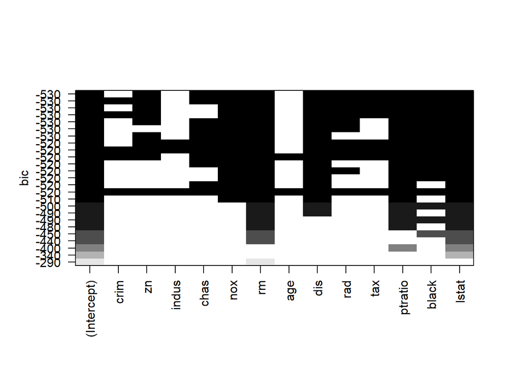

```r
plot(subset_result, scale="bic")
```

Each row represents a model. Black indicates that a variable is included in the model, while white indicates that it is not. The argument `scale = ""` can be “Cp”, “adjr2”, “r2” or “bic”.

What is the problem with best subset regression? If there are n independent variables, the number of possible nonempty subsets is 2^n - 1. If you try a best subset regression with more than 50 variables, you might need to wait for your entire life to get the result.

## 5.3 Forward/Backward/Stepwise Regression Using AIC

To perform the Forward/Backward/Stepwise Regression in R, we need to define the starting points:

```r
nullmodel=lm(medv~1, data=Boston_train)
fullmodel=lm(medv~., data=Boston_train)
```

nullmodel is the model with no varaible in it, while fullmodel is the model with every variable in it.

### 5.3.1 Backward Elimination

```r
model_step_b <- step(fullmodel,direction='backward')
```

```
## Start:  AIC=1444.3
## medv ~ crim + zn + indus + chas + nox + rm + age + dis + rad +
##     tax + ptratio + black + lstat
##
##           Df Sum of Sq   RSS    AIC
## - age      1      0.32 10230 1442.3
## - indus    1      0.82 10230 1442.3
## <none>                 10230 1444.3
## - crim     1    115.69 10345 1447.4
## - chas     1    183.30 10413 1450.4
## - tax      1    193.31 10423 1450.8
## - zn       1    255.02 10485 1453.5
## - black    1    280.75 10510 1454.6
## - rad      1    446.68 10676 1461.7
## - nox      1    496.19 10726 1463.8
## - ptratio  1   1040.20 11270 1486.4
## - dis      1   1187.21 11417 1492.3
## - rm       1   1749.17 11979 1514.1
## - lstat    1   2067.68 12297 1526.1
##
## Step:  AIC=1442.31
## medv ~ crim + zn + indus + chas + nox + rm + dis + rad + tax +
##     ptratio + black + lstat
##
##           Df Sum of Sq   RSS    AIC
## - indus    1      0.84 10231 1440.3
## <none>                 10230 1442.3
## - crim     1    116.07 10346 1445.5
## - chas     1    182.99 10413 1448.4
## - tax      1    194.74 10425 1448.9
## - zn       1    263.23 10493 1451.9
## - black    1    280.78 10511 1452.6
## - rad      1    453.77 10684 1460.1
## - nox      1    543.06 10773 1463.8
## - ptratio  1   1048.01 11278 1484.7
## - dis      1   1279.74 11510 1493.9
## - rm       1   1813.20 12043 1514.6
## - lstat    1   2349.44 12579 1534.4
##
## Step:  AIC=1440.35
## medv ~ crim + zn + chas + nox + rm + dis + rad + tax + ptratio +
##     black + lstat
##
##           Df Sum of Sq   RSS    AIC
## <none>                 10231 1440.3
## - crim     1    117.03 10348 1443.5
## - chas     1    187.38 10418 1446.6
## - tax      1    237.65 10468 1448.8
## - zn       1    264.11 10495 1450.0
## - black    1    280.12 10511 1450.6
## - rad      1    489.57 10720 1459.6
## - nox      1    574.40 10805 1463.2
## - ptratio  1   1055.15 11286 1483.0
## - dis      1   1354.61 11585 1494.9
## - rm       1   1824.77 12056 1513.0
## - lstat    1   2352.90 12584 1532.5
```

### 5.3.2 Forward Selection

```r
model_step_f <- step(nullmodel, scope=list(lower=nullmodel, upper=fullmodel), direction='forward')
```

```
## Start:  AIC=2021.72
## medv ~ 1
##
##           Df Sum of Sq   RSS    AIC
## + lstat    1   20852.9 17679 1669.2
## + rm       1   18677.0 19855 1722.0
## + ptratio  1    9444.9 29087 1895.8
## + indus    1    9085.1 29447 1901.4
## + tax      1    8232.4 30300 1914.4
## + nox      1    6963.5 31569 1933.0
## + crim     1    5939.4 32593 1947.5
## + age      1    5650.1 32882 1951.6
## + rad      1    5059.6 33473 1959.7
## + zn       1    5005.3 33527 1960.4
## + black    1    4533.7 33998 1966.8
## + dis      1    2261.1 36271 1996.2
## + chas     1     940.9 37591 2012.5
## <none>                 38532 2021.7
##
## Step:  AIC=1669.23
## medv ~ lstat
##
##           Df Sum of Sq   RSS    AIC
## + rm       1    3628.1 14051 1566.7
## + ptratio  1    2222.0 15457 1610.1
## + dis      1     616.9 17062 1655.1
## + chas     1     546.5 17133 1656.9
## + tax      1     217.6 17462 1665.6
## + black    1     205.7 17474 1665.9
## + age      1     185.2 17494 1666.4
## + zn       1     146.4 17533 1667.5
## + indus    1     140.3 17539 1667.6
## + crim     1      78.9 17600 1669.2
## <none>                 17679 1669.2
## + rad      1       8.0 17671 1671.0
## + nox      1       0.3 17679 1671.2
##
## Step:  AIC=1566.72
## medv ~ lstat + rm
##
```

[output cut: 109 more lines]

```
##
##         Df Sum of Sq   RSS    AIC
## + crim   1   117.029 10231 1440.3
## <none>               10348 1443.5
## + indus  1     1.795 10346 1445.5
## + age    1     0.728 10347 1445.5
##
## Step:  AIC=1440.35
## medv ~ lstat + rm + ptratio + dis + nox + black + chas + rad +
##     zn + tax + crim
##
##         Df Sum of Sq   RSS    AIC
## <none>               10231 1440.3
## + indus  1   0.83562 10230 1442.3
## + age    1   0.33279 10230 1442.3
```

### 5.3.3 Stepwise Selection (Output Omitted)

```r
model_step_s <- step(nullmodel, scope=list(lower=nullmodel, upper=fullmodel), direction='both')
```

One caution when comparing fit statistics using AIC, the definition varies by program/procedure.

```r
extractAIC(model_1)
```

```
## [1]   14.000 1444.298
```

```r
AIC(model_1)
```

```
## [1] 2737.533
```

> Exercise
> 1. Comparing in-sample and out-of-sample performance between these reduced models.
> 2. Conduct 10-fold cross validation on the full sample and compare the CV scores.
- For pros and cons of variable/model selection using the common fit statistics: (adjusted) $R^2$, MSE, AIC, BIC, etc. refer to Ch9 in “Applied Linear Regression Models” by Kutner et al.
- For other variable selection methods refer to section 3.4 - 3.8 of [“Elements of Statistical Learning” (Free Online)](http://www-stat.stanford.edu/~tibs/ElemStatLearn/).

go to top

## 5.4 Lasso and Elastic net

Two of the state-of-the-art automatic variable selection techniques of predictive modeling , Lasso [1] and Elastic net [2], are provided in the *glmnet* package. These method are in general better than the stepwise regressions, especially when dealing with large amount of predictor variables.

For a more theoretical review of these techniques refer to section 3.4 - 3.8 of [“Elements of Statistical Learning” (Free Online)](http://www-stat.stanford.edu/~tibs/ElemStatLearn/). For more details of the glmnet package you can watch [Professor Trevor Hastie’s presentation](http://www.youtube.com/watch?v=BU2gjoLPfDc).

In short, Lasso and Elastic net are solving this optimization problem [2] :

$$\begin{array}
{rl}
\hat{\beta}= & \underset{\beta}{\text{argmin}}|y-X\beta|^2_2 \\
\text{subject to} & (1-\alpha)|\beta|_1+\alpha|\beta|^2\le t
\end{array}$$

Note that when solving the above problem without the constraint we have a familiar least square regression model. When the constraint is added, depending on how large $t$ is, some of the “unimportant” predictor variables will become 0 and are forced out of the model. Lasso is a special case of Elastic net when $\alpha = 0$.

Two of the most important tuning parameters are $t$ and $\alpha$ in the above equation.

- $t$ is controlled by adding the left hand side of the constraint as a penalty term in the objective. By default 100 different penalty parameter $\lambda$ are evaluated. When $\lambda$ is large less variables are included in the model. You can choose the $\lambda$ yourself if you know how many variables you want in the model or use cv.glmnet to conduct a cross-validation.
- The default $alpha = 1$ (the definition is the opposite of the above equation) gives Lasso penalty, which is fine in most cases.

The case for using elastic net is [3]:

- Use elastic net when variables are highly correlated and you want to select more than one predictor variables from a group of correlated variables. Lasso tends to select one variable from a group and ignore the others.
- Use elastic net when there are more variables than observations.

Here we demonstrate Lasso on Boston Housing data. For parsimony we are not using training/testing split in this example.

Note: If you have a binary response you can use *family= “binomial”* option in the glmnet() function.

```r
library(MASS)
```

```r
data(Boston);
colnames(Boston)
```

```
##  [1] "crim"    "zn"      "indus"   "chas"    "nox"     "rm"      "age"
##  [8] "dis"     "rad"     "tax"     "ptratio" "black"   "lstat"   "medv"
```

```r
install.packages('glmnet')
```

```r
library(glmnet)
```

glmnet does not take data frame as input, so we have to specify the x matrix and y vector.

```r
lasso_fit = glmnet(x = as.matrix(Boston[, -c(which(colnames(Boston)=='medv'))]), y = Boston$medv, alpha = 1)
#lambda = 0.5
coef(lasso_fit,s=0.5)
```

```
## 14 x 1 sparse Matrix of class "dgCMatrix"
##                        1
## (Intercept) 14.177440452
## crim        -0.013381578
## zn           .
## indus        .
## chas         1.565138250
## nox         -0.014613729
## rm           4.237566862
## age          .
## dis         -0.081500956
## rad          .
## tax          .
## ptratio     -0.739162698
## black        0.005955512
## lstat       -0.513806573
```

```r
#lambda = 1
coef(lasso_fit,s=1)
```

```
## 14 x 1 sparse Matrix of class "dgCMatrix"
##                        1
## (Intercept) 15.283205304
## crim         .
## zn           .
## indus        .
## chas         0.074725982
## nox          .
## rm           3.862575281
## age          .
## dis          .
## rad          .
## tax          .
## ptratio     -0.620249174
## black        0.001973097
## lstat       -0.496888716
```

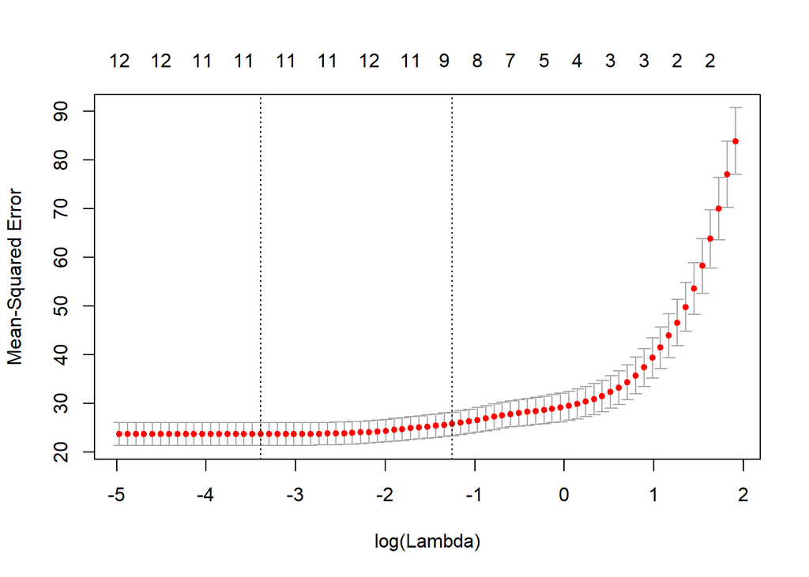

```r
#use 5-fold cross validation to pick lambda
cv_lasso_fit = cv.glmnet(x = as.matrix(Boston[, -c(which(colnames(Boston)=='medv'))]), y = Boston$medv, alpha = 1, nfolds = 5)
plot(cv_lasso_fit)
```

The best $\lambda$ (or *s*) is given by:

```r
cv_lasso_fit$lambda.min
```

```
## [1] 0.03373254
```

Given a selected *s* you can use *predict()* this way to get prediction:

```r
Boston.insample.prediction = predict(lasso_fit, as.matrix(Boston[, -c(which(colnames(Boston)=='medv'))]), s = cv_lasso_fit$lambda.min)
```

> **Exercise**: For a high dimensional dataset having n<p (n=200, p=500), is it possible to fit a linear regression on that directly? Fit a model with first five variables. How about LASSO variable selection?

[1]: Tibshirani, R. (1996). Regression shrinkage and selection via the lasso. Journal of the Royal Statistical Society. Series B (Methodological), 267-288. [2]: Zou, H., & Hastie, T. (2005). Regularization and variable selection via the elastic net. Journal of the Royal Statistical Society: Series B (Statistical Methodology), 67(2), 301-320.  
[3]: http://www.stanford.edu/~hastie/TALKS/enet_talk.pdf “Regularization and Variable Selection via the Elastic Net”

go to top

# 6 Simulation Exercise

Assume mean function $E(y|x)= 5 + 1.2*x_1 +3*x_2$

- Generate data with $x_1 \sim N(2,.4^2)$, $x_2 \sim N(-1, .1^2)$, sample size $n=200$, and error term $\varepsilon\sim N(0,\sigma^2)$, where $\sigma^2=1$.

```r
#sample code for hw2 p3
#monte carlo simulation
n <- 200 #sample size
m <- 100 #number of simulation iterations
#part i) simulate predictors X

#part ii)
for(j in 1:m){
  #simulate the error term m=100 times...
  #generate response vector y with error term per iteration
  lm.out <- ?? #fit linear regression
  betaMatrix[j,] <- lm.out$coefficients
  mysummary <- summary(lm.out)
  listMSE[j] <- mysummary$sigma^2 #get MSE per iteration
  }
#part iii) compute MSE bias etc
beta_mean <- apply(betaMatrix,2,mean)
beta_var <- apply(betaMatrix,2,var)
```

go to top

# 7 Cross Validation

Cross validation is an alternative approach to training/testing split. For k-fold cross validation, the dataset is divided into k parts. Each part serves as the test set in each iteration and the rest serve as training set. The out-of-sample performance measures from the k iterations are averaged.

Note

1. We use the **entire** dataset for cross validation
2. We need to use glm instead of lm to fit the model (if we want to use cv.glm fucntion in boot package)
3. The default measure of performance is the Mean Squared Error (MSE). If we want to use another measure we need to define a cost function.

## 7.1 5-fold Cross Validation

```r
library(boot)
model_2 <- glm(medv~indus + rm, data = Boston)
cv.glm(data = Boston, glmfit = model_2, K = 5)$delta[2]
```

```
## [1] 39.7475
```

## 7.2 LOOCV (Leave-one-out Cross Validation)

```r
cv.glm(data = Boston, glmfit = model_2, K = nrow(Boston))$delta[2]
```

```
## [1] 39.94028
```

## 7.3 5-fold Cross Validation Using MAE

Here we need to define a MAE cost function. The function takes 2 input vectors, pi = predicted values, r = actual values.

```r
model_2 <- glm(medv~indus + rm, data = Boston)

MAE_cost <- function(pi, r){
  return(mean(abs(pi-r)))
}

cv.glm(data = Boston, glmfit = model_2, cost = MAE_cost, K = 5)$delta[2]
```

```
## [1] 4.272952
```

Another package DAAG also does cross validation. It prints out the performance in each fold and gives you a plot at the end. But currently I cannot figure out how to get the cross-validation error programmatically.

```r
install.packages('DAAG')
```

```r
library(DAAG)
```

```r
model_2 <- lm(medv~indus + rm, data = Boston)
cv.lm(df=Boston, form.lm = model_2, m=3)
```

go to top

# 8 Diagnostic Plots

The diagnostic plots are not as important when regression is used in predictive (supervised) data mining as when it is used in economics. However it is still good to know:

1. What the diagnostic plots should look like when no assumption is violated?
2. If there is something wrong, what assumptions are possibly violated?
3. What implications does it have on the analysis?
4. (How) can I fix it?

Roughly speaking, the table summarizes what you should look for in the following plots

| Plot Name | Good |
| --- | --- |
| Residual vs. Fitted | No pattern, scattered around 0 line |
| Normal Q-Q | Dots fall on dashed line |
| Residual vs. Leverage | No observation with large Cook’s distance |

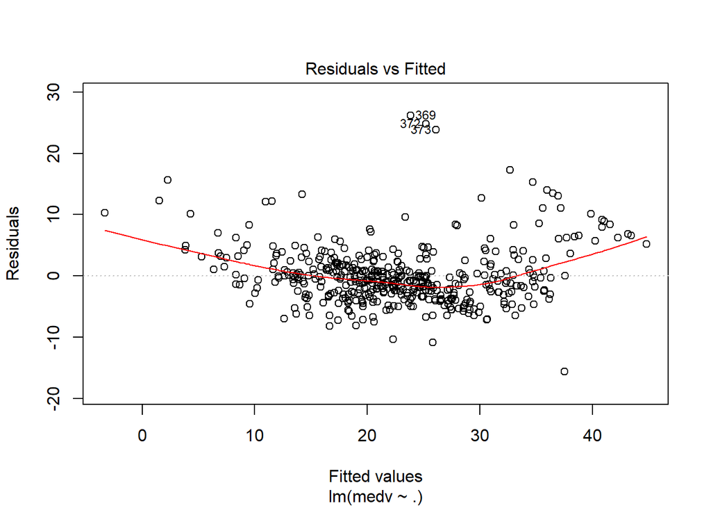

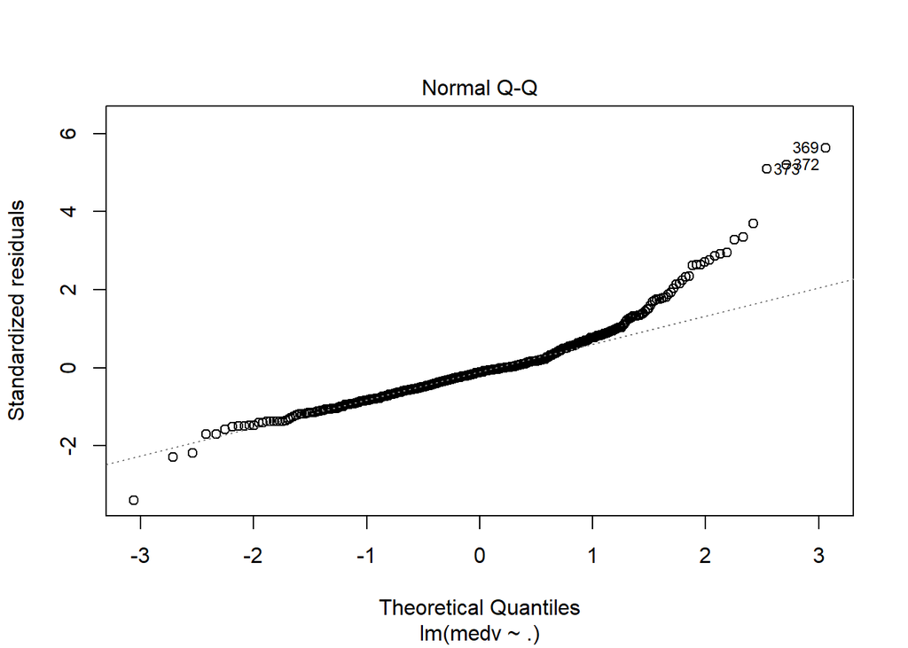

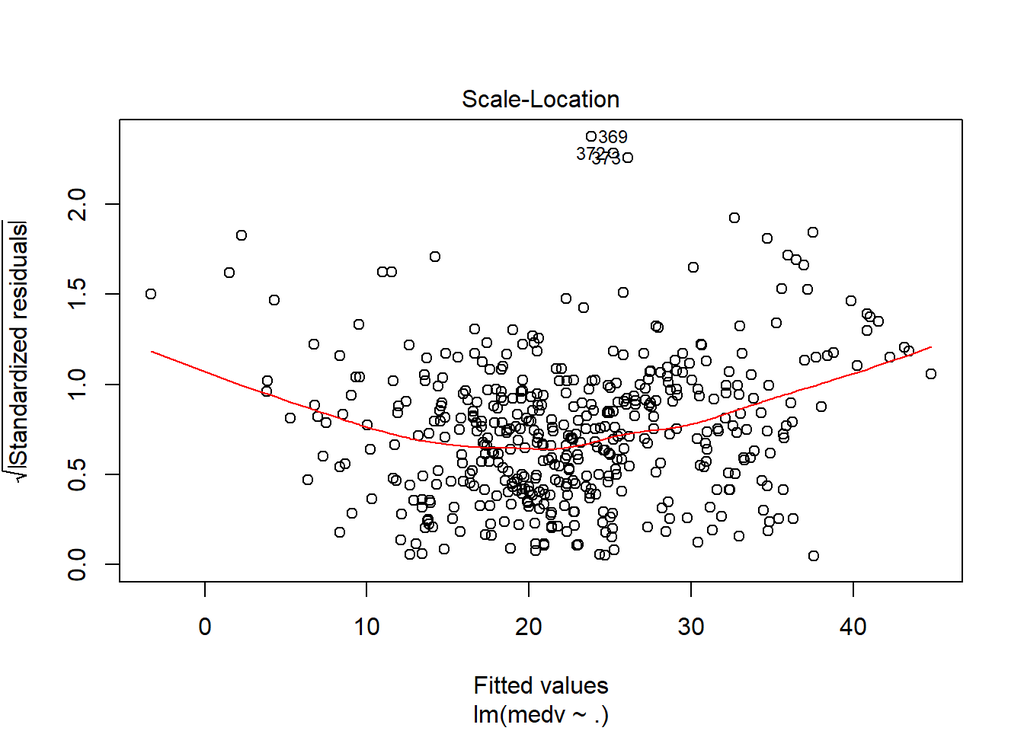

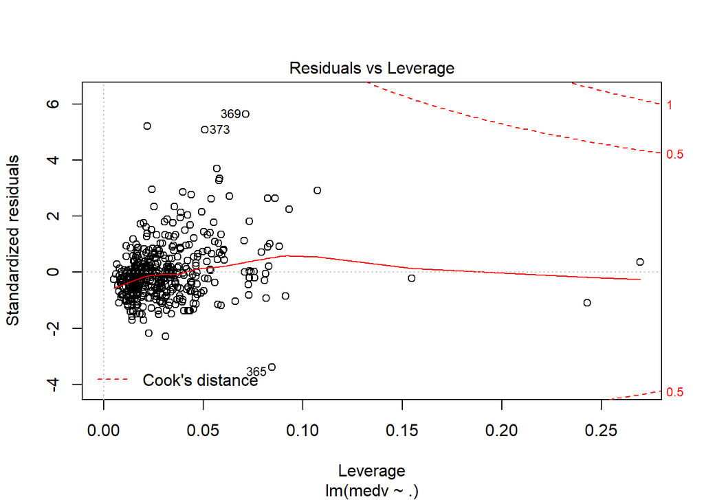

```r
plot(model_1)
```

go to top